# seaborn 실습2

### 8-2. 선형관계를 표현하는 regression 라인 그리기

옵션에 **kind='reg'**을 추가해 주기

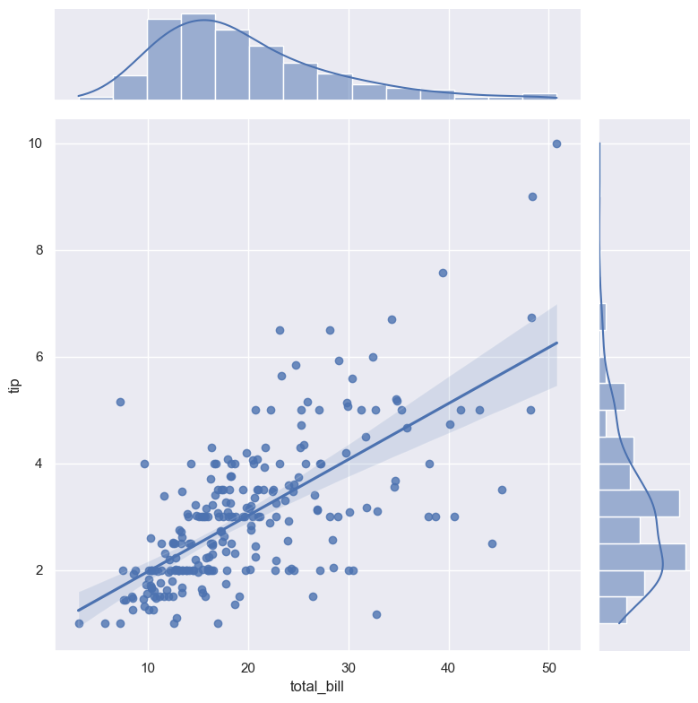

```python
sns.jointplot(data=tips, x="total_bill", y="tip", height=8, kind="reg")
plt.show()
```

### 8-3. hex 밀도 보기

**kind='hex'** 옵션을 통해 hex 모양의 밀도를 확인할 수 있음.

- 변수의 값들을 2D 육각형 그래프로 표현
- 각 육각형의 색상은 해당 영역에 속한 데이터 포인트의 빈도수를 나타냄.
- 빈도가 높은 영역은 더 진한 색상으로 표현, 변수 간의 밀집도와 분포를 시각화하며
- 두 변수 간의 상관 관계를 대략적으로 확인할 수 있

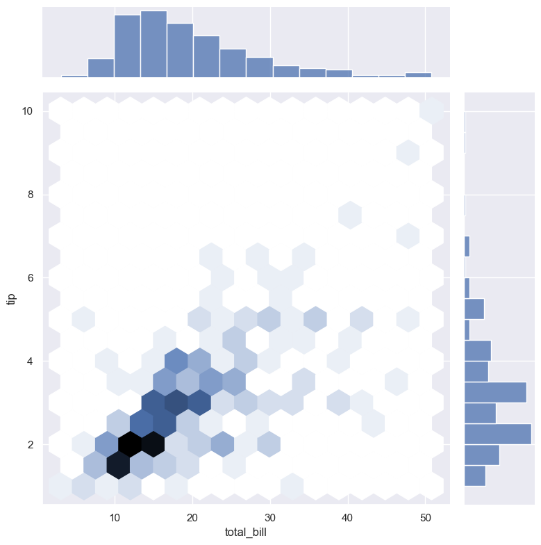

```python
sns.jointplot(data=tips, x="total_bill", y="tip", height=8, kind="hex")
plt.show()
```

### 8-4. 등고선 모양으로 밀집도 확인하기

**kind='kde'** 옵션으로 데이터의 밀집도를 보다 부드러운 선으로 확인할 수 있음

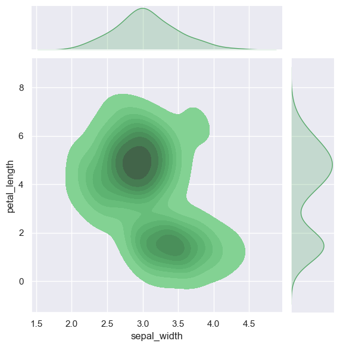

```python
iris = sns.load_dataset('iris')
# sns.jointplot(data=iris, x="sepal_width", y="petal_length", height=6, kind="kde", color="g")
sns.jointplot(data=iris, x="sepal_width", y="petal_length", height=6, kind="kde", color="g", fill=True)
plt.show()
```